# Using PCA/CAP to Visualize Population Genetic Data

Chris Reyes, Kostas Kontodimas, Xuqing Chen

March 19, 2019

Version Control: R version 3.5.1 (2018-07-02) “vegan” 2.5.4 “adegenet” 2.1.1

```r
###Loading packages and setting up
library(vegan); #packageVersion("vegan"); citation("vegan")
library(adegenet); #packageVersion("adegenet"); citation("adegenet")
```

```r
#Loading bam files
setwd("C:/Users/clr3y/Desktop/BI598/PartII_radseq/PartII_radseq/radseq_plotting") #change to wherever your bam files are located
bams=read.table("bamscl")[,1] # list of bam files
goods=c(1:length(bams))
head(goods)
```

```
## [1] 1 2 3 4 5 6
```

```r
#Loading individual to population correspondences
i2p=read.table("bamscl_site.txt",sep="\t") # 2-column tab-delimited table of individual assignments to populations; must be in the same order as samples in the bam list or vcf file.
head(i2p)
```

```
##                     V1   V2
## 1 MNWI_51.trim.bt2.bam MNWI
## 2 MNWI_53.trim.bt2.bam MNWI
## 3 MNWI_55.trim.bt2.bam MNWI
## 4 MNWI_56.trim.bt2.bam MNWI
## 5 MNWI_57.trim.bt2.bam MNWI
## 6 MNWI_59.trim.bt2.bam MNWI
```

```r
row.names(i2p)=i2p[,1]
i2p=i2p[goods,]
site=i2p[,2]
head(i2p)
```

```
##                                        V1   V2
## MNWI_51.trim.bt2.bam MNWI_51.trim.bt2.bam MNWI
## MNWI_53.trim.bt2.bam MNWI_53.trim.bt2.bam MNWI
## MNWI_55.trim.bt2.bam MNWI_55.trim.bt2.bam MNWI
## MNWI_56.trim.bt2.bam MNWI_56.trim.bt2.bam MNWI
## MNWI_57.trim.bt2.bam MNWI_57.trim.bt2.bam MNWI
## MNWI_59.trim.bt2.bam MNWI_59.trim.bt2.bam MNWI
```

```r
#Setting up colors for plotting
palette(topo.colors(length(unique(site))))
colors=as.numeric(as.factor(site))
colpops=as.numeric(as.factor(sort(unique(site))))
```

```r
#clustering / PCoA based on identity by state (IBS) based on single read resampling (for low and/or uneven coverage)

ma = as.matrix(read.table("myresult.ibsMat")) #Load IBS data
ma=ma[goods,goods]
head(ma)
```

```
##            V1       V2       V3       V4       V5       V6       V7
## [1,] 0.000000 0.252246 0.259406 0.257129 0.261381 0.259378 0.256725
## [2,] 0.252246 0.000000 0.253599 0.251693 0.264532 0.255272 0.256713
## [3,] 0.259406 0.253599 0.000000 0.250514 0.264842 0.260148 0.254455
## [4,] 0.257129 0.251693 0.250514 0.000000 0.258674 0.266592 0.253989
## [5,] 0.261381 0.264532 0.264842 0.258674 0.000000 0.261965 0.259587
## [6,] 0.259378 0.255272 0.260148 0.266592 0.261965 0.000000 0.253346
##            V8       V9      V10      V11      V12      V13      V14
## [1,] 0.260887 0.259581 0.256952 0.258292 0.248931 0.261551 0.255668
## [2,] 0.264444 0.254536 0.257064 0.251303 0.242469 0.253886 0.261226
## [3,] 0.258203 0.260533 0.257299 0.257934 0.254251 0.253337 0.260388
## [4,] 0.261251 0.269435 0.261744 0.260454 0.247961 0.265731 0.257844
## [5,] 0.261669 0.251071 0.262858 0.260615 0.252992 0.253098 0.250425
## [6,] 0.257451 0.259279 0.256227 0.259684 0.249767 0.254946 0.258874
##           V15      V16      V17      V18      V19      V20      V21
```

[output cut: 111 more lines]

```r
length(ma)
```

```
## [1] 15376
```

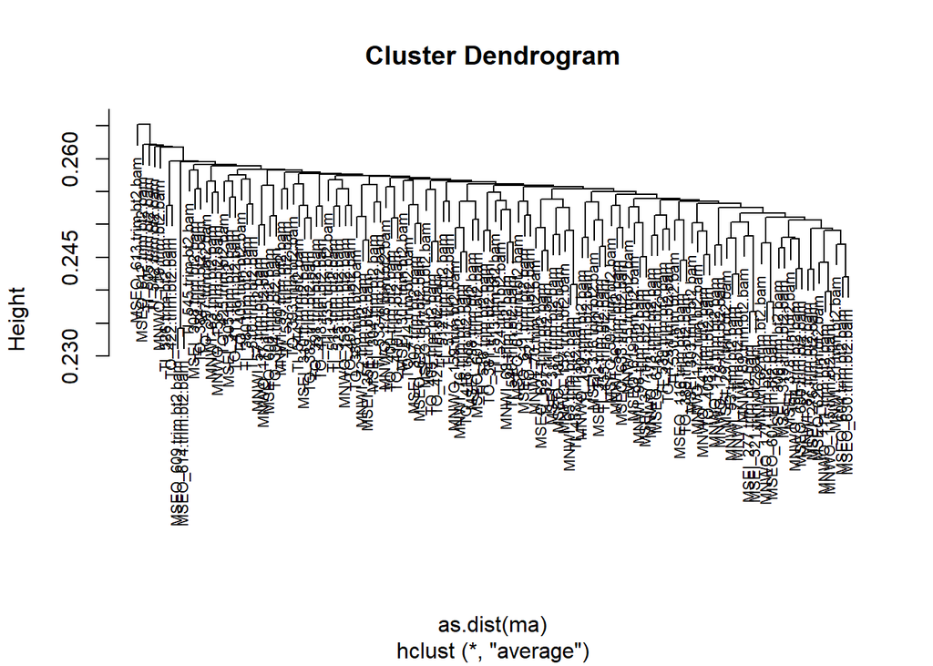

```r
dimnames(ma)=list(bams[goods],bams[goods]) #Change the row and column names
hc=hclust(as.dist(ma),"ave") #clustering by average distance
plot(hc,cex=0.7) #plot dendrogram
```

Based on the clustering, we suspect that two samples are potentially clones and upon further investigation should be removed from further analysis.

```r
#Performing PCoA
head(site)
```

```
## [1] MNWI MNWI MNWI MNWI MNWI MNWI
## Levels: MNWI MNWO MSEI MSEO TI TO
```

```r
conds=data.frame(cbind(site))
head(conds)
```

```
##   site
## 1    1
## 2    1
## 3    1
## 4    1
## 5    1
## 6    1
```

```r
pp0=capscale(ma~1)

adonis(ma~site,conds) #significance of by-site divergence
```

```
##
## Call:
## adonis(formula = ma ~ site, data = conds)
##
## Permutation: free
## Number of permutations: 999
##
## Terms added sequentially (first to last)
##
##            Df SumsOfSqs  MeanSqs F.Model      R2 Pr(>F)
## site        1    0.0371 0.037079  1.1212 0.00911  0.001 ***
## Residuals 122    4.0348 0.033072         0.99089
## Total     123    4.0718                  1.00000
## ---
## Signif. codes:  0 '***' 0.001 '**' 0.01 '*' 0.05 '.' 0.1 ' ' 1
```

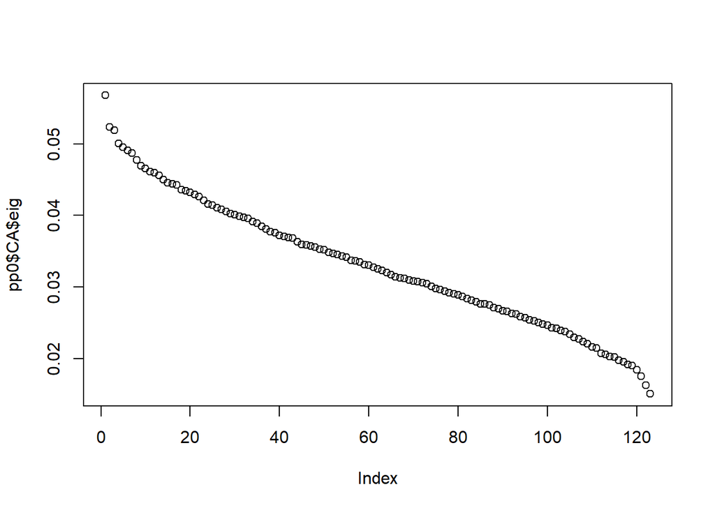

```r
#Plot eigenvectors
plot(pp0$CA$eig)
```

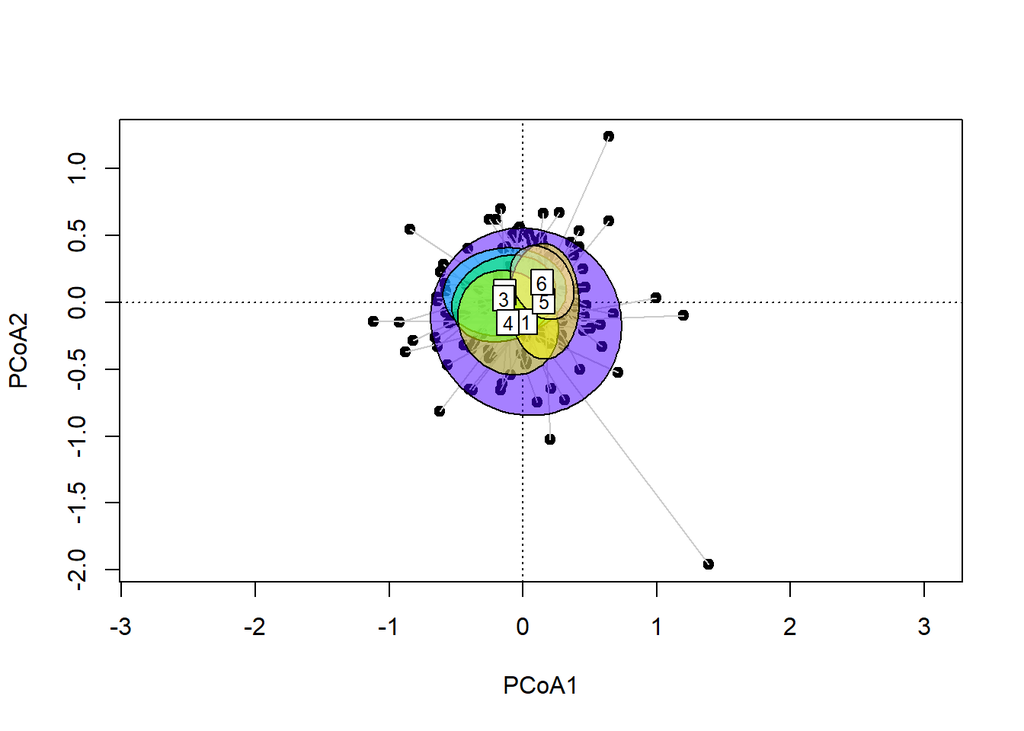

```r
#Plotting the PCoA
axes2plot=c(1,2)
cmd=pp0
plot(cmd,choices=axes2plot,display="sites",type="n", xlab="PCoA1", ylab="PCoA2") # choices-axes to display
points(cmd,choices=axes2plot,display="sites",scaling="species", pch=19,transp(col=colors,alpha=0.7))
#ordihull(cmd,choices= axes2plot,groups= conds$grp,draw="polygon",col=1+as.numeric(unique(as.factor(conds$grp))),label=T)
ordispider(cmd,choices= axes2plot,groups=conds$site,col="grey80")
ordiellipse(cmd,choices= axes2plot,groups= conds$site,draw="polygon",col=colpops,label=T)
```

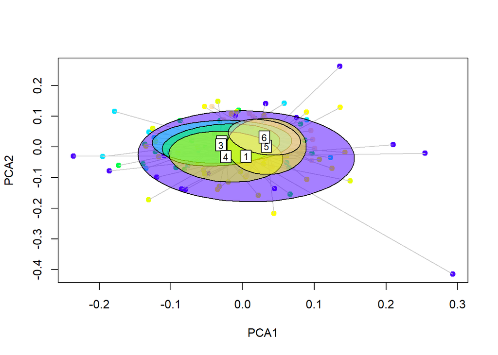

```
## integer(0)
```

```r
#Plot the PCA unscaled to identify outliers
plot(cmd$CA$u[,axes2plot],pch=19,col=colors, xlab="PCA1", ylab="PCA2")
ordispider(cmd$CA$u[,axes2plot],groups=conds$site,col="grey80")
ordiellipse(cmd$CA$u[,axes2plot],groups= conds$site,draw="polygon",col=colpops,label=T)
identify(cmd$CA$u[,axes2plot],labels=colnames(ma),n=3,cex=0.7)
```

By-site divergence was found to be significant (p=.001), but it fails to explain a majority of the variance (R-squared=.00911). Sites cluster but also overlap to varying extents.

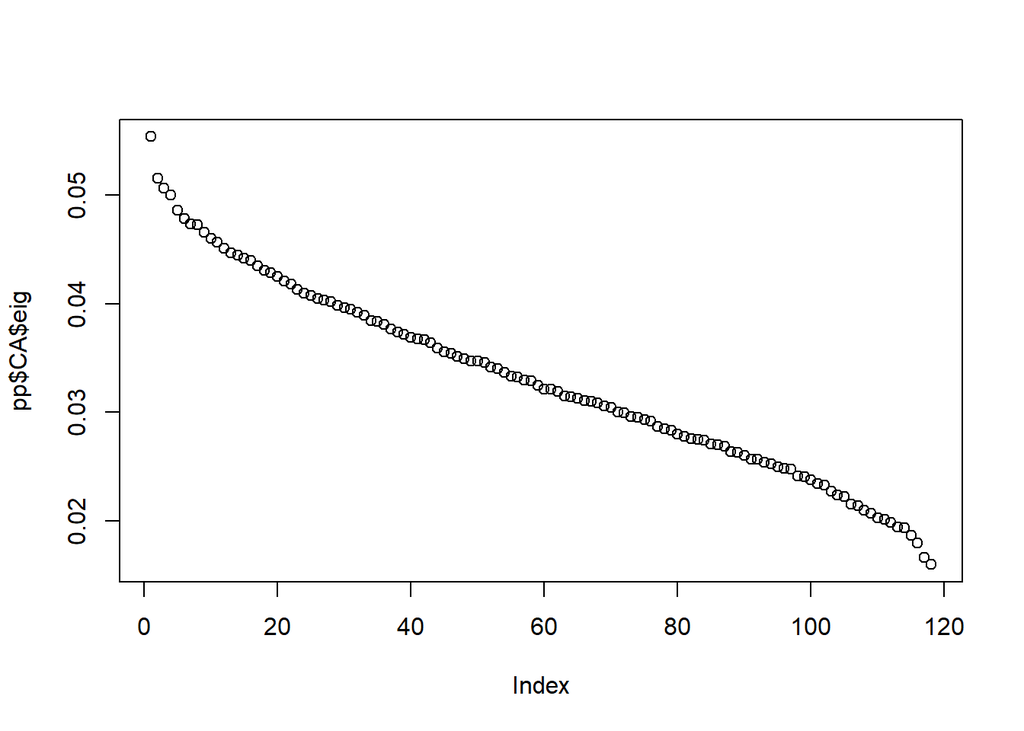

```r
#Performing CAP
pp=capscale(ma~site,as.factor(conds))

#Plot eigenvectors
plot(pp$CA$eig)
```

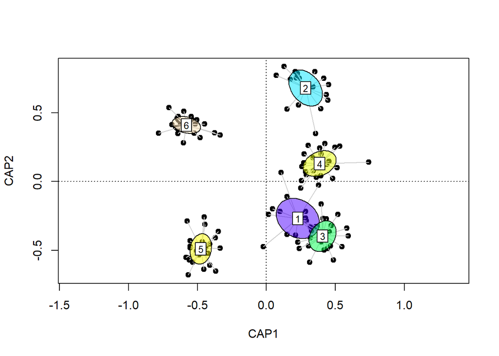

```r
#Plotting the CAP
axes2plot=c(1,2)
plot(pp,choices=axes2plot,display="sites",type="n") # choices-axes to display
points(pp,choices=axes2plot,display="sites",scaling="species", pch=19,transp(col=colors,alpha=0.7))
#ordihull(pp,choices= axes2plot,groups= conds$grp,draw="polygon",col=1+as.numeric(unique(as.factor(conds$grp))),label=T)
ordispider(pp,choices= axes2plot,groups=conds$site,col="grey80")
ordiellipse(pp,choices= axes2plot,groups= conds$site,draw="polygon",col=colpops,label=T)
```

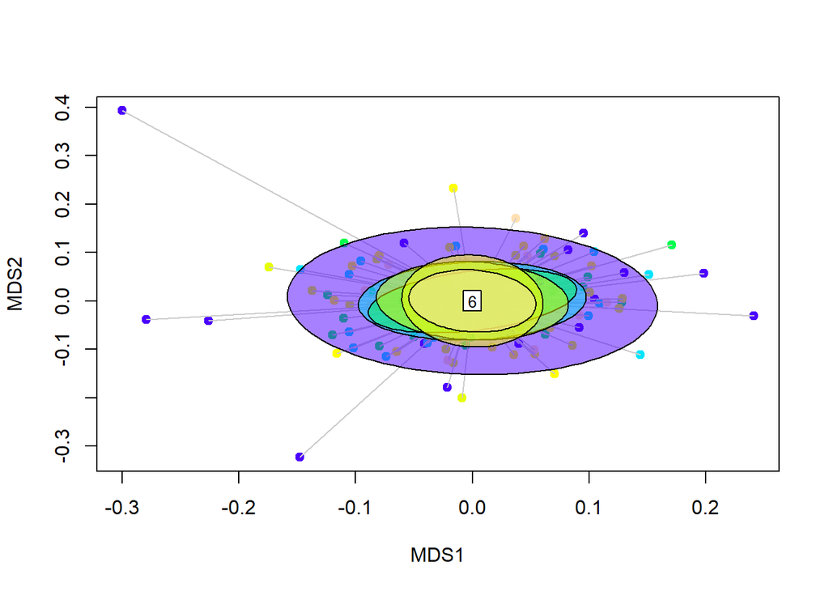

```
## integer(0)
```

```r
#Plot the MDS unscaled to identify outliers
plot(pp$CA$u[,axes2plot],pch=19,col=colors)
ordispider(pp$CA$u[,axes2plot],groups=conds$site,col="grey80")
ordiellipse(pp$CA$u[,axes2plot],groups= conds$site,draw="polygon",col=colpops,label=T)
identify(pp$CA$u[,axes2plot],labels=colnames(ma),n=3,cex=0.7)
```

Sites are clearly distinguishable and only the two inshore sites from Mo’orea (1 and 3) overlap. Inshore locations (1,3,and 5) cluster closer together regardless of site and the same is true for offshore locations (2,4,and 6). The sites from Tahiti (5 and 6) are clearly separated from the sites from Mo’orea (1-4).

```r
#Clustering / PCA based on covariance based on single read resampling
##An alternate method to clustering by IBS
co = as.matrix(read.table("myresult.covMat")) # covariance based on single-read resampling
co =co[goods,goods]
dimnames(co)=list(bams[goods],bams[goods])
```

```r
#Performing PCA (using covariate)
conds=data.frame(cbind(site))
pp0=capscale(as.dist(1-cov2cor(co))~1)

#Significance of by-site divergence, based on 1-correlation as distance
adonis(as.dist(1-cov2cor(co))~site,conds)
```

```
##
## Call:
## adonis(formula = as.dist(1 - cov2cor(co)) ~ site, data = conds)
##
## Permutation: free
## Number of permutations: 999
##
## Terms added sequentially (first to last)
##
##            Df SumsOfSqs MeanSqs F.Model      R2 Pr(>F)
## site        1     0.567 0.56741  1.1162 0.00907  0.001 ***
## Residuals 122    62.016 0.50833         0.99093
## Total     123    62.583                 1.00000
## ---
## Signif. codes:  0 '***' 0.001 '**' 0.01 '*' 0.05 '.' 0.1 ' ' 1
```

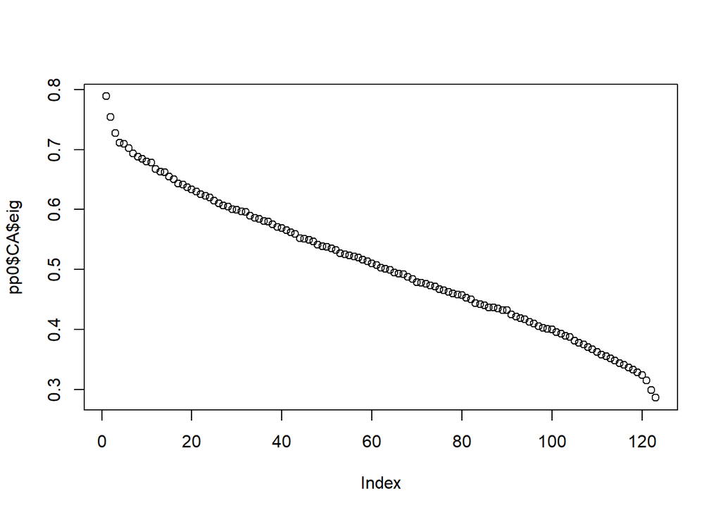

```r
#Plot eigenvectors
plot(pp0$CA$eig)
```

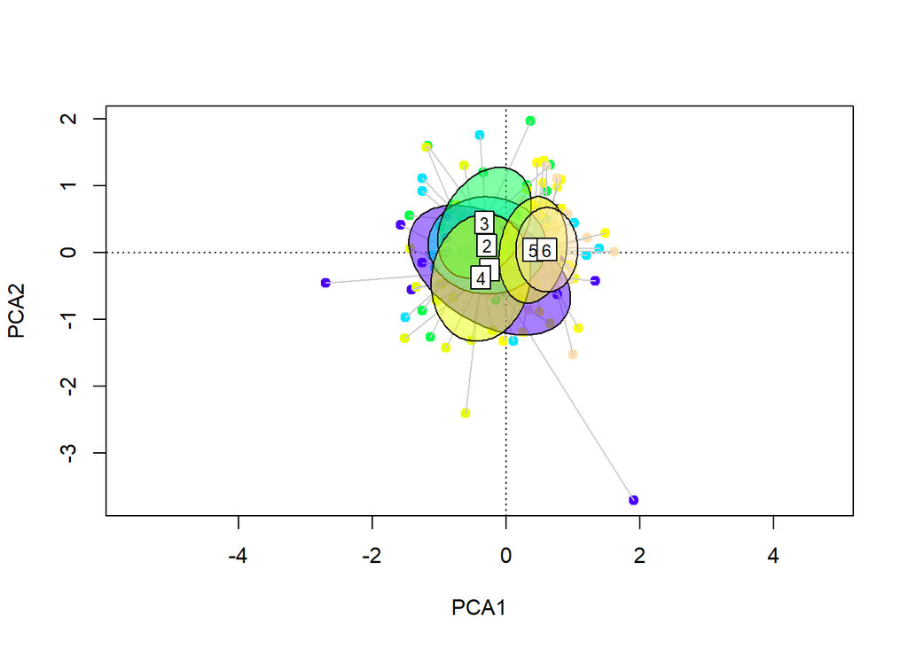

```r
#Plot PCA
axes2plot=c(1,2)
cc=pp0
plot(cc,choices=axes2plot,type="n", xlab="PCA1", ylab="PCA2") # choices - axes to display
points(cc,choices=axes2plot,pch=19,col=colors)
#ordihull(cc,choices= axes2plot,groups= conds$grp,draw="polygon",col=1+as.numeric(unique(as.factor(conds$grp))),label=T)
ordispider(cc,choices= axes2plot,groups=conds$site,col="grey80")
ordiellipse(cc,choices= axes2plot,groups= conds$site,draw="polygon",col=colpops,label=T)
```

The same is true as before. All sites cluster independently but overlap. By-site divergence is significant (p=.001), but fails to explain a majority of the variance (R-squared=.00907).

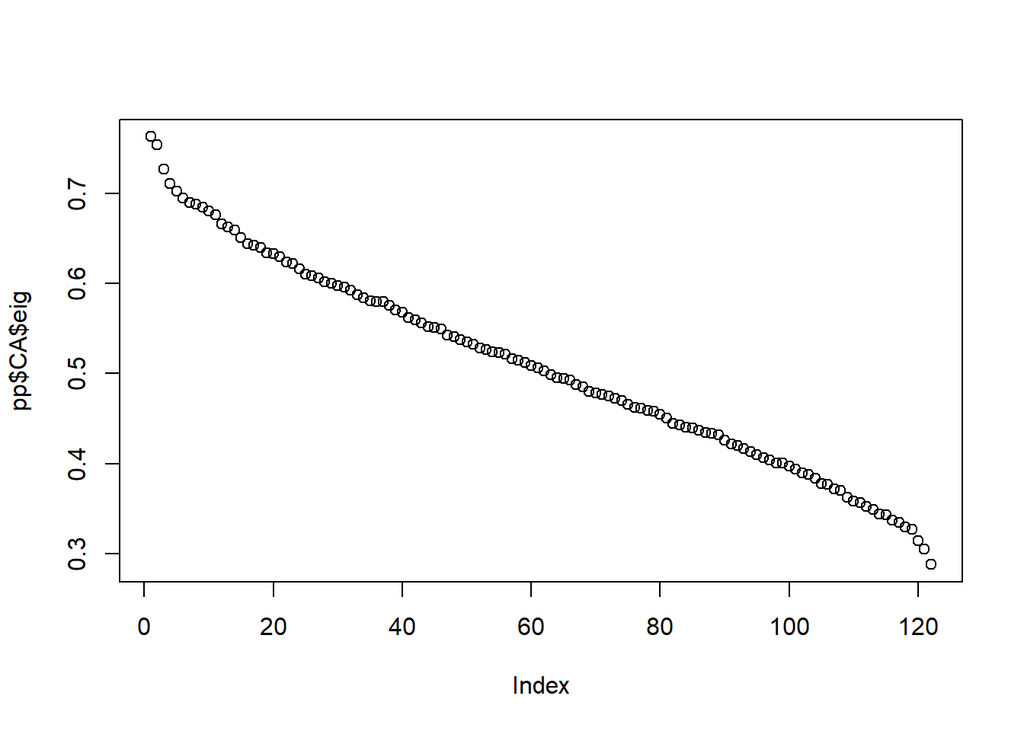

```r
#Performing CAP (using covariate)
pp=capscale(as.dist(1-cov2cor(co))~site,conds) # CAP

#Plot eigenvectors
plot(pp$CA$eig)
```

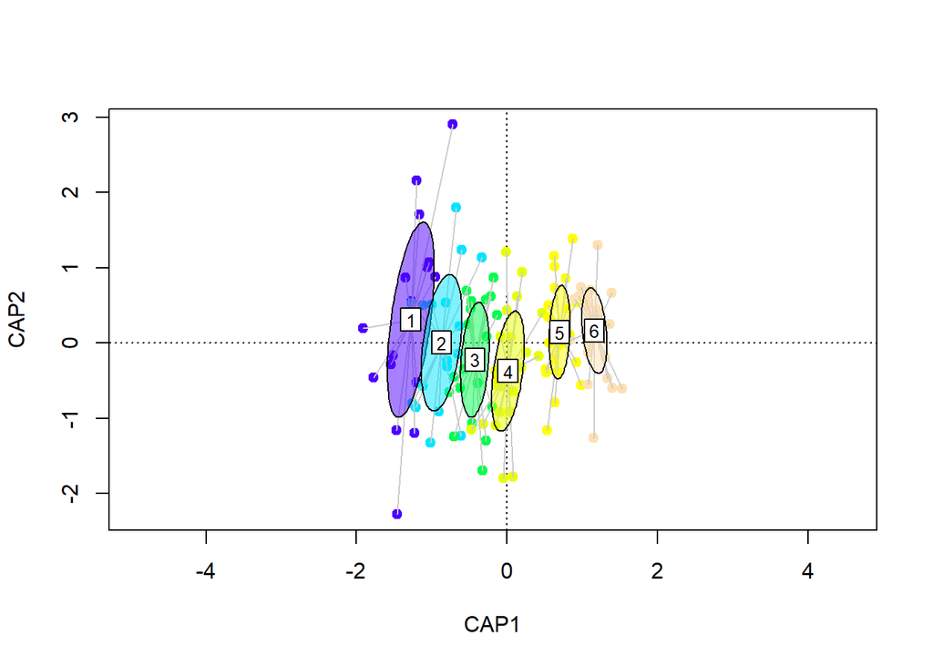

```r
#Plot CAP
axes2plot=c(1,2)
cv=pp
plot(cv,choices=axes2plot,type="n", xlab="CAP1", ylab="CAP2") # choices - axes to display
points(cv,choices=axes2plot,pch=19,col=colors)
#ordihull(cv,choices= axes2plot,groups= conds$grp,draw="polygon",col=1+as.numeric(unique(as.factor(conds$grp))),label=T)
ordispider(cv,choices= axes2plot,groups=conds$site,col="grey80")
ordiellipse(cv,choices= axes2plot,groups= conds$site,draw="polygon",col=colpops,label=T)
```

CCA: canonical correspondence analysis A CCA analysis is not possible to be done on this data. CCA analysis requires the use of a chi-square matrix and is interested in assessing how much of the variability can be explained by continuous environmental variables. Factors that are discrete or deterministic, such as site and inner v. outer reef, cannot be used in CCA analysis. This type of analysis would be plausible for assessing the effects of temperature, depth, elevation, or any environmental variable with a gradient of values.

Conclusion: We wanted to assess the connectivity between populations of corals in Mo’orea and Tahiti from different sites and reef zones. Analyzing the data via IBS and covariance using PCA, we found high connectivity and gene flow between populations from both sites and reef zones. Populations from Tahiti showed only a slight divergence from populations from Mo’orea. By-site divergence was found to be significant but failed to explain variance. Using CAP, by contrast, we found distinct divisions between populations from Mo’orea and Tahiti when analyzing both IBS and covariance. Covariance mainly showed the connectivity between the sites on the respective islands but did not show differences between reef zones. IBS showed clearly divisions between reef zones in addition to divisions by islands. Given that we saw such stark differences between PCA and CAP, future studies should be done implementing other analysis methods to further assess conncectivity between populations.

References:

Jombart T, Ahmed I. (2011). adegenet 1.3-1: new tools for the analysis of genome-wide SNP data. Bioinformatics. doi: 10.1093/bioinformatics/btr521

Jombart T. (2008) adegenet: a R package for the multivariate analysis of genetic markers. Bioinformatics 24: 1403-1405. doi: 10.1093/bioinformatics/btn129

Oksanen J, Blanchet FG, Friendly M, Kindt R, Legendre P, McGlinn D, Minchin PR, O’Hara RB, Simpson GL, Solymos P, Stevens MHH, Szoecs E, Wagner H. (2019).vegan: Community Ecology Package. R package version 2.5-4. https://CRAN.R-project.org/package=vegan